# Estimating leaf traits with PLSR

Jose Eduardo Meireles

July 2026

```r
library("pls")
```

## The idea

Leaf reflectance carries a fingerprint of a plant’s chemistry and structure: water and dry matter absorb in the shortwave infrared, pigments absorb in the visible, and internal structure scatters in the near infrared. Because those signals are spread across many strongly-correlated bands, the workhorse for turning spectra into trait estimates is **Partial Least Squares Regression (PLSR)**. PLSR builds a handful of latent components that capture the directions in the spectrum most predictive of the trait, side-stepping the fact that you have far more bands than samples.

`spectrolab` is the **data layer** here: it reads, cleans, aligns, and carries your spectra as a tidy `spectra` object. The heavy modeling machinery (cross-validated component selection, jackknifed coefficients, ensembles) is intentionally *not* baked into `spectrolab` – that belongs in the planned `spectrolab.models` companion. This vignette is the bridge: it shows how to hand a `spectra` object to `pls`, fit a model, and – the part people get wrong – **apply the fitted coefficients back to new spectra correctly**.

We use the bundled `spec_matrix_example` (50 samples, 400–2500 nm, reflectance-like) and **simulate** two traits so the whole workflow is reproducible and honest about what “recovering a trait” means.

```r
s = as_spectra(spec_matrix_example, name_idx = 1)
s
```

```
#> spectra object
#> number of samples: 50
#> bands: 400 to 2500 (2101 bands)
#> metadata: none
#>
#>            400                401                402
#> species_7  0.0409999850000255 0.0410392346804256 0.04106549994583
#> species_8  0.0409962044286894 0.0410353382475394 0.0410614986994235
#> species_5  0.0410009904793496 0.0410404205990898 0.0410668814132104
#> species_7  0.0409983698664643 0.0410375234860887 0.0410636927693175
#> species_10 0.0409991416221446 0.0410383501198347 0.0410645753123711
#>            403                404                405
#> species_7  0.0411176913920641 0.0412088689409777 0.0413002645716231
#> species_8  0.0411135913885245 0.0412046591541176 0.0412958756998439
#> species_5  0.0411192648210274 0.0412106251159301 0.0413022209479067
#> species_7  0.0411157918560658 0.0412068761381853 0.0412981496209886
#> species_10 0.0411167280801826 0.0412078653476602 0.0412992056048533
#>            406                ...
#> species_7  0.0414047926564346
#> species_8  0.0414001880928309
#> species_5  0.0414069455006203
#> species_7  0.041402543837837
#> species_10 0.0414036712997242
```

## Simulating example traits

We invent two traits as a **linear function of a few physically-motivated bands** plus calibrated Gaussian noise. LMA (leaf mass per area) is driven by shortwave-infrared dry-matter/water bands; chlorophyll by a green/red-edge contrast. The band predictors are mean-centered so the intercept reads as the mean trait value, and the noise is tuned so PLSR recovers the traits at a realistic test-set R² (~0.85–0.92), **not** a suspiciously perfect ~1.0.

```r
## #############################################################################
## ## SIMULATED TRAITS -- replace this block with your measured LMA/Chl        ##
## ## The weights and noise below are ILLUSTRATIVE, not real calibrations.     ##
## #############################################################################
simulate_traits = function(s){
    set.seed(1)
    X = as.matrix(s)                                   # 50 x 2101, cols named by band
    b = function(nm) X[, which.min(abs(as.numeric(colnames(X)) - nm))]
    n = nrow(X)

    ## LMA (g/m^2): SWIR dry-matter / water bands
    lma = 120 + 900*(b(1730) - mean(b(1730))) +
                700*(b(1980) - mean(b(1980))) + rnorm(n, 0, 6)

    ## Chl (ug/cm^2): green vs red-edge contrast
    chl =  45 + 2100*(b(550) - mean(b(550))) -
                2800*(b(705) - mean(b(705))) + rnorm(n, 0, 4)

    data.frame(LMA = lma, Chl = chl)
}

traits = simulate_traits(s)
summary(traits)
```

```
#>       LMA              Chl
#>  Min.   : 86.24   Min.   :19.63
#>  1st Qu.:113.19   1st Qu.:38.55
#>  Median :123.54   Median :45.94
#>  Mean   :120.60   Mean   :45.47
#>  3rd Qu.:127.84   3rd Qu.:49.77
#>  Max.   :142.16   Max.   :75.72
```

The simulated ranges (LMA ~85–145 g/m², Chl ~20–75 µg/cm²) are in the right ballpark for real leaves, but the numbers are fabricated. Everything downstream works identically on measured traits – just drop your own `data.frame` in place of `traits`, with one row per sample in `s`.

## Fitting

We hold out a test set the model never sees, then fit a **multivariate** PLSR (both traits at once) on the training spectra. `pls::plsr()` accepts the trait matrix as the response and the spectral matrix as the predictor.

```r
set.seed(42)
train = sort(sample(nrow(s), 35))
test  = setdiff(seq_len(nrow(s)), train)

Xtrain = as.matrix(s[train, ])       # 35 x 2101, bands as columns
Ytrain = as.matrix(traits[train, ])  # 35 x 2   (LMA, Chl)
Xtest  = as.matrix(s[test, ])
Ytest  = as.matrix(traits[test, ])

fit = pls::plsr(Ytrain ~ Xtrain, ncomp = 15, validation = "LOO")
```

### Choosing the number of components

Too few components underfit; too many overfit. We pick the number that minimizes the cross-validated error. `pls::selectNcomp()`’s one-sigma heuristic only supports a *univariate* response, so for a multivariate fit we minimize the **average relative RMSEP** across traits directly (each trait’s RMSEP is scaled by its own intercept-only error so the two traits, which live on different scales, count equally).

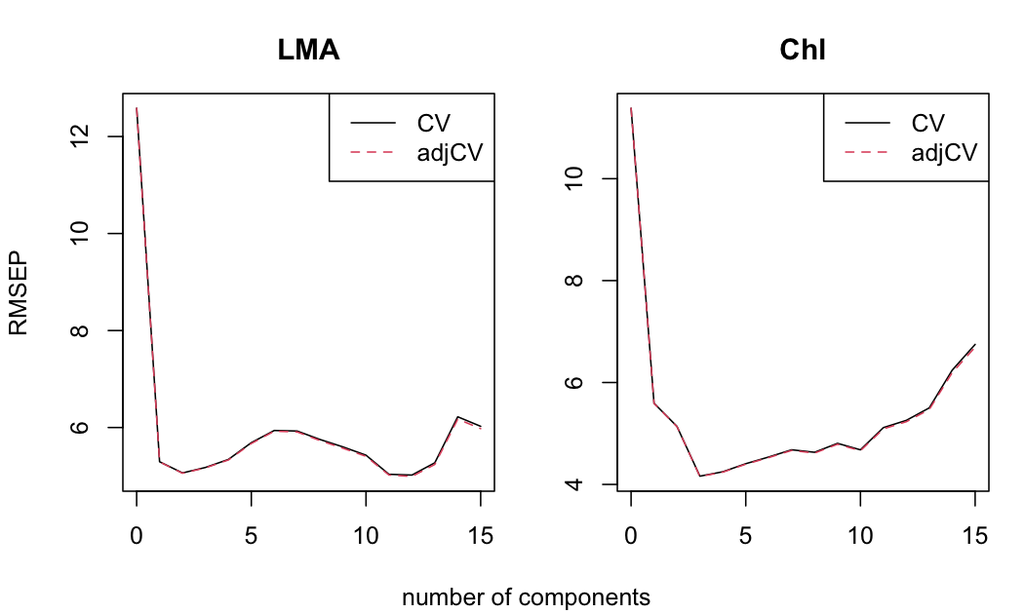

```r
pls::validationplot(fit, val.type = "RMSEP", legendpos = "topright")
```

```r
cv = pls::RMSEP(fit, estimate = "CV")$val[1, , ]   # traits x (0..ncomp)
k  = which.min(colMeans(cv / cv[, 1])) - 1
k
```

```
#> 3 comps
#>       3
```

## Validating

The honest performance number is on the **held-out test set**, not the training fit. We predict the test spectra and compare observed vs predicted.

```r
pred_test = predict(fit, ncomp = k, newdata = Xtest)[, , 1]   # 15 x 2

perf = function(obs, prd){
    c(R2   = cor(obs, prd)^2,
      RMSE = sqrt(mean((obs - prd)^2)),
      bias = mean(prd - obs))
}
round(t(sapply(colnames(Ytest), function(j) perf(Ytest[, j], pred_test[, j]))), 3)
```

```
#>        R2  RMSE   bias
#> LMA 0.850 5.282  1.146
#> Chl 0.922 3.826 -1.630
```

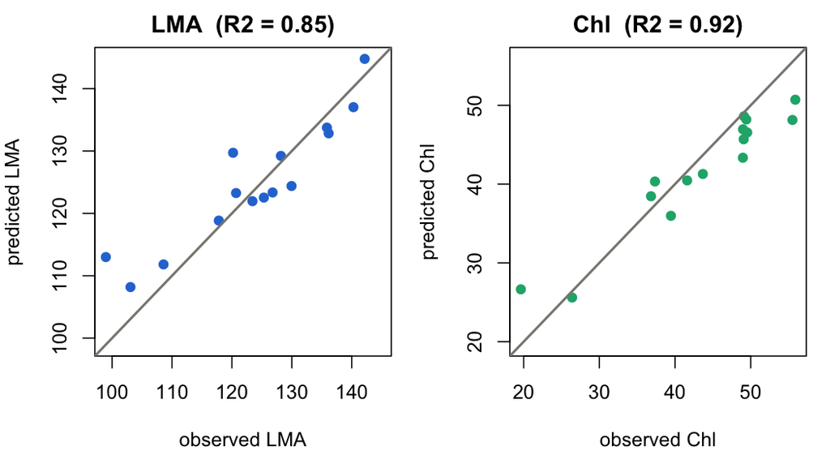

```r
op = par(mfrow = c(1, 2), mar = c(4, 4, 2, 1))
for(j in seq_along(colnames(Ytest))){
    tr = colnames(Ytest)[j]
    o  = Ytest[, tr]; p = pred_test[, tr]
    lim = range(o, p)
    plot(o, p, xlim = lim, ylim = lim, pch = 19, col = spec_pal[j],
         xlab = paste("observed", tr), ylab = paste("predicted", tr),
         main = sprintf("%s  (R2 = %.2f)", tr, cor(o, p)^2))
    abline(0, 1, col = spec_muted, lwd = 2)   # 1:1 line
}
```

```r
par(op)
```

The points hug the 1:1 line with the scatter we deliberately built in – a believable model, not a memorized one.

## The coefficient spectra

A fitted PLSR is, in the end, **one coefficient per band per trait**. Plotting those coefficients over wavelength shows *which* bands the model leans on. We color by sign with the diverging palette (`spec_div`) and shade the canonical spectral regions with `plot_regions()`.

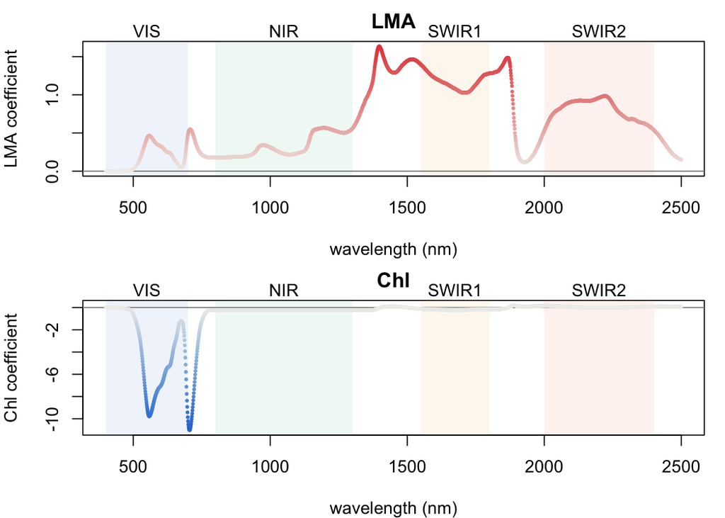

```r
B = coef(fit, ncomp = k)          # 2101 x 2 x 1 array (no intercept)
wl = bands(s)

div_cols = function(v){
    rng = max(abs(v))
    idx = round((v / rng + 1) / 2 * 254) + 1     # -max -> 1 (blue), +max -> 255 (red)
    spec_div(255)[idx]
}

op = par(mfrow = c(2, 1), mar = c(4, 4, 2, 1))
for(j in seq_len(dim(B)[2])){
    tr = dimnames(B)[[2]][j]
    bc = B[, j, 1]
    plot(wl, bc, type = "n", xlab = "wavelength (nm)",
         ylab = paste(tr, "coefficient"), main = tr)
    plot_regions(s, col = spec_region_tints)     # shaded VIS/NIR/SWIR1/SWIR2
    abline(h = 0, col = spec_muted)
    points(wl, bc, col = div_cols(bc), pch = 19, cex = 0.35)
}
```

```r
par(op)
```

Read these as *where the trait signal lives*. The LMA coefficients carry weight in the SWIR (the dry-matter/water bands we built in), while the Chl coefficients concentrate in the visible / red-edge. Note that PLSR **smears** weight across neighboring, highly-correlated bands rather than spiking at a single wavelength – so treat the coefficient spectrum as a region-level story, not a claim about individual bands.

## Applying the model to new spectra

This is the section people get wrong. A PLSR prediction is just `intercept + spectrum %*% slopes`. Get the intercept, the band alignment, or the matrix orientation wrong and you get confidently wrong numbers.

Ask for the coefficients **with the intercept** via `intercept = TRUE`. For a multivariate fit this returns a `(p+1) x q x 1` array whose first row is the per-trait intercept.

```r
newspec = s[test, ]                              # pretend these are "new" leaves
Bi   = coef(fit, ncomp = k, intercept = TRUE)    # (2101+1) x 2 x 1
Bmat = Bi[, , 1]                                 # 2102 x 2 ; row 1 = intercept
dim(Bmat)
```

```
#> [1] 2102    2
```

Predict by prepending a column of 1s (for the intercept) to the spectral matrix and multiplying:

```r
Xnew = as.matrix(newspec)
pred = cbind(1, Xnew) %*% Bmat                   # n x 2

## Verify it is byte-for-byte what predict() computes.
stopifnot(all.equal(unname(pred),
                    unname(predict(fit, ncomp = k, newdata = Xnew)[, , 1]),
                    tolerance = 1e-8))
```

The `stopifnot()` passes: our hand-rolled prediction equals `predict()`.

### The spectrolab-native form

`spectrolab` overloads `%*%` for `spectra` (see `?\`%*%.spectra``), so you can multiply a`spectra` object directly by the* slope* block and then add the intercept. It returns a **plain matrix**, since rows are samples but columns are now traits, not bands.

```r
pred_native = newspec %*% Bmat[-1, ]             # spectra %*% slopes  -> matrix
pred_native = sweep(pred_native, 2, Bmat[1, ], "+")   # add per-trait intercept

stopifnot(all.equal(unname(pred_native), unname(pred), tolerance = 1e-8))
class(pred_native)
```

```
#> [1] "matrix" "array"
```

### Band alignment is your job

The coefficient vector is indexed **by position**, not by band label. If a new spectrum sits on a different band grid, the multiplication is either an error or – worse – silently meaningless. Suppose the new data came off a coarser instrument:

```r
coarse = resample(newspec, seq(400, 2500, by = 5), fwhm = 5)  # 5 nm grid
c(coarse = length(bands(coarse)), model = length(bands(s)))
```

```
#> coarse  model
#>    421   2101
```

Predicting directly fails, because 421 bands cannot multiply a 2101-band coefficient block:

```r
cbind(1, as.matrix(coarse)) %*% Bmat
```

```
#> Error in `cbind(1, as.matrix(coarse)) %*% Bmat`:
#> ! non-conformable arguments
```

The fix is to resample **back onto the model’s band grid** before predicting:

```r
fixed      = resample(coarse, bands(s), fwhm = 1)   # back to the model's 1 nm grid
pred_fixed = cbind(1, as.matrix(fixed)) %*% Bmat
round(cor(Ytest[, "LMA"], pred_fixed[, "LMA"])^2, 3)
```

```
#> [1] 0.85
```

### Reattaching predictions

`%*%` and the manual form both return a **plain matrix** with no sample names, so reattach identity yourself – set row names from the spectra, then bind to a `data.frame` with any grouping you need.

```r
rownames(pred) = names(newspec)
predicted = data.frame(species = names(newspec), pred, row.names = NULL)
head(predicted)
```

```
#>     species      LMA      Chl
#> 1 species_1 108.1832 48.14167
#> 2 species_9 133.7495 45.69255
#> 3 species_8 112.9971 38.45727
#> 4 species_9 118.8461 48.20231
#> 5 species_6 144.7699 26.64460
#> 6 species_3 137.0318 40.46759
```

## Predicted traits across species

With predictions back in a `data.frame`, ordinary R plots the rest. Here are the predicted traits by species, colored with the shared `species_cols()` helper.

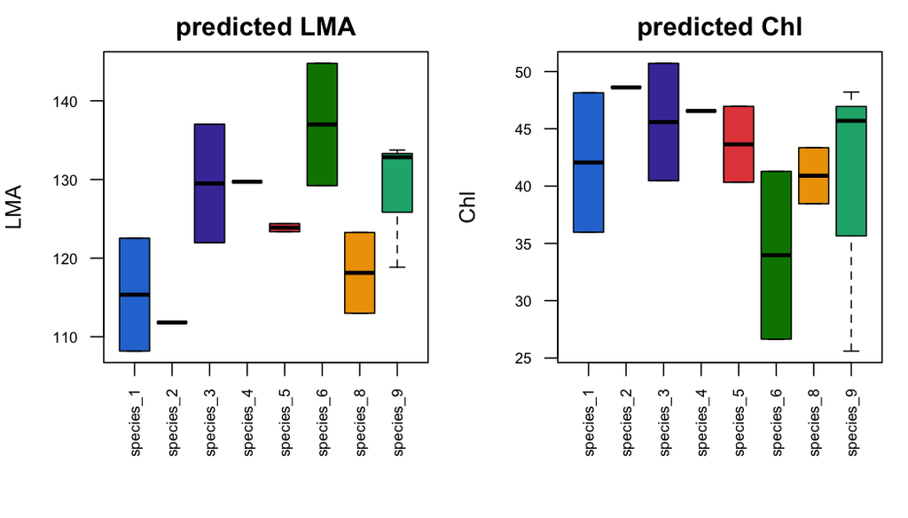

```r
sp   = factor(predicted$species)
pal  = species_cols(newspec)[!duplicated(predicted$species)]
names(pal) = predicted$species[!duplicated(predicted$species)]

op = par(mfrow = c(1, 2), mar = c(6, 4, 2, 1))
for(tr in c("LMA", "Chl")){
    boxplot(predicted[[tr]] ~ sp, col = pal[levels(sp)],
            xlab = "", ylab = tr, main = paste("predicted", tr),
            las = 2, cex.axis = 0.7)
}
```

```r
par(op)
```

(With only a couple of samples per species in this toy set, read the spread with caution – the point is the *plumbing*, not the ecology.)

## Gotchas

- **The intercept is mandatory.** Dropping it does not just shift the answer a little; it removes the entire baseline. Watch the bias explode:

  ```r
  pred_no_intercept = as.matrix(newspec) %*% Bmat[-1, ]     # forgot the 1s column
  round(mean(pred_no_intercept[, "LMA"] - Ytest[, "LMA"]), 1)   # huge bias
  ```

  ```
  #> [1] 117.6
  ```

- **Band alignment is on you.** Coefficients are position-indexed. Always `resample()` new spectra onto the model’s exact `bands()` grid first; a mismatch is an error at best and nonsense at worst.
- **`%*%` returns a plain matrix**, not a `spectra` – because the columns are traits, not bands. Reattach sample names and metadata yourself.
- **Never apply a reflectance model to radiance or raw DN.** The bundled Acer files, for instance, are *radiance*; a model trained on reflectance would produce garbage. Match the physical quantity (`quantity()`), band grid, and units before predicting.
- **Small n.** With 35 training samples this is a demo, not a calibration. Real trait models need many more samples, spatially/temporally independent validation, and ideally jackknifed uncertainty.
- **These traits are simulated.** The weights and noise were chosen to make the workflow reproducible – they are not a real LMA or chlorophyll calibration.
- **A unified alternative.** `caret::train(method = "pls")` wraps `pls` with built-in resampling and tuning if you want a single interface for cross-validation and preprocessing.